# Tutorial: Install Fest

# Twitter API

The twitter API is definitily the one most heavily used by researhcers. First, let’s register on Twitter. For this you need to have a normal twitter account. Then you should go to the developer website https://developer.twitter.com/ to create a special account. On this site, you click on the top corner where it says dashboard app

[figure not shown]

Then you click again to apply. And select the student option, as shown below.

[figure not shown]

From this point on, twitter will ask you for information such as your phone number, address, and why you want the developer account. Be honest, what we’re doing is allowed by the twitter rules. Write that you are taking a course on data science and will use twitter with educational purposes. Every time twitter asks you to refer a website, put the address of our github page.

One catch. Twitter accepts requests in English only. Don’t waste time trying to write very elaborate English. Be objective, and use google translator if you need help. After that, your order will go for review, and it may be authorized immediately, or twitter will ask you for more information. You should start this request as soon as possible.

Once your developer account is approved, you can log in again and click the “Create a new app” button in the upper right corner of the screen. Our goal is not to create a full-featured app at this point, but simply to get the necessary credentials to start making some simple calls to the Twitter API. If all goes well, you will see the following image. Those are your credentials. don’t share with anyone. During the course, we will learn together how to use them.

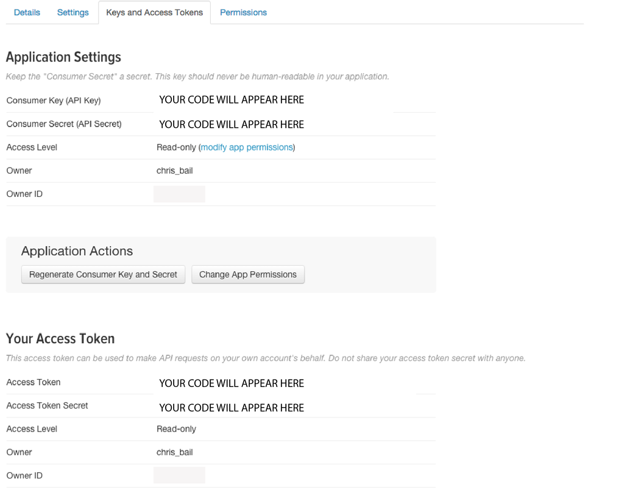

# Crossfire API

The Crossfire is a data laboratory, a collaborative digital platform that records the incidence of armed violence in the metropolitan regions of Rio de Janeiro and Recife. Instead of answering emails providing the data, they created an API to allow access to the data collected in the project. We are going to use their API, so we need to request a registration.

Here you register and request the api password https://api.fogocruzado.org.br/register. It’s as simple as creating an email. After registering, you will receive an email, and you will be able to login to the site. Once authenticated, this code below will return your api password.

```r
# api fogo cruzado
library(httr)
library(jsonlite)
library(tidyverse)
# Getting you access token.

get_jwt <- httr::POST("https://api.fogocruzado.org.br/api/v1/auth/login",
                 query = list(email = "your_email", password = "yourpassword"))

token <- httr::content(get_jwt)$access_token


# token = your password for the API
```

[output not shown]